# Multiple Fundulus killifish osmotic challenge RNAseq, Differential Expression by species

Lisa K. Johnson

3/9/2018

## Importing quantification files, by species

The following is just DE analysis with the *Adinia xenica* species as example species to test. Will later do this on each species separate, then look at up-down trends per species, as a quantifiable trait to compare between clades in a phylogenetic context. This is just to identify candidate genes to be interested in for downstream analysis.

These are the quantification files, and whether they exist:

```
## [1] "~/Documents/UCDavis/Whitehead/RNAseq_15killifish/salmon_denovo_by_species/A_xenica/A_xenica_BW_1.quant/quant.sf"
## [2] "~/Documents/UCDavis/Whitehead/RNAseq_15killifish/salmon_denovo_by_species/A_xenica/A_xenica_BW_2.quant/quant.sf"
## [3] "~/Documents/UCDavis/Whitehead/RNAseq_15killifish/salmon_denovo_by_species/A_xenica/A_xenica_BW_3.quant/quant.sf"
## [4] "~/Documents/UCDavis/Whitehead/RNAseq_15killifish/salmon_denovo_by_species/A_xenica/A_xenica_FW_1.quant/quant.sf"
## [5] "~/Documents/UCDavis/Whitehead/RNAseq_15killifish/salmon_denovo_by_species/A_xenica/A_xenica_FW_2.quant/quant.sf"
## [6] "~/Documents/UCDavis/Whitehead/RNAseq_15killifish/salmon_denovo_by_species/A_xenica/A_xenica_FW_3.quant/quant.sf"
## [7] "~/Documents/UCDavis/Whitehead/RNAseq_15killifish/salmon_denovo_by_species/A_xenica/A_xenica_transfer_1.quant/quant.sf"
## [8] "~/Documents/UCDavis/Whitehead/RNAseq_15killifish/salmon_denovo_by_species/A_xenica/A_xenica_transfer_2.quant/quant.sf"
## [9] "~/Documents/UCDavis/Whitehead/RNAseq_15killifish/salmon_denovo_by_species/A_xenica/A_xenica_transfer_3.quant/quant.sf"
```

```
## [1] TRUE TRUE TRUE TRUE TRUE TRUE TRUE TRUE TRUE
```

# De novo assemblies and annotations

De novo assemblies were run with Trinity (version 2.2.0) and annotated with dammit (version 1.0 with translated amino acid database from Fundulus heteroclitus, NCBI version - need to run again with Don Gilbert’s kfish2rae5g aa fasta file to get Funhe id).

This is the number of contigs:

```
## [1] 362781      1
```

This is the number of annotated contigs:

```
## [1] 161802      8
```

Summarizing by gene:

```
## reading in files with read_tsv
```

```
## 1 2 3 4 5 6 7 8 9
## removing duplicated transcript rows from tx2gene
## transcripts missing from tx2gene: 289325
## summarizing abundance
## summarizing counts
## summarizing length
```

```
## [1] 29421     9
```

## Experimental Design

```
##                           condition
## A_xenica_BW_1.quant              BW
## A_xenica_BW_2.quant              BW
## A_xenica_BW_3.quant              BW
## A_xenica_FW_1.quant              FW
## A_xenica_FW_2.quant              FW
## A_xenica_FW_3.quant              FW
## A_xenica_transfer_1.quant        TR
## A_xenica_transfer_2.quant        TR
## A_xenica_transfer_3.quant        TR
```

## Dispersion

```
## using counts and average transcript lengths from tximport
```

```
## using 'avgTxLength' from assays(dds), correcting for library size
```

```
##      [,1]
## [1,] "Intercept"
## [2,] "condition_FW_vs_BW"
## [3,] "condition_TR_vs_BW"
```

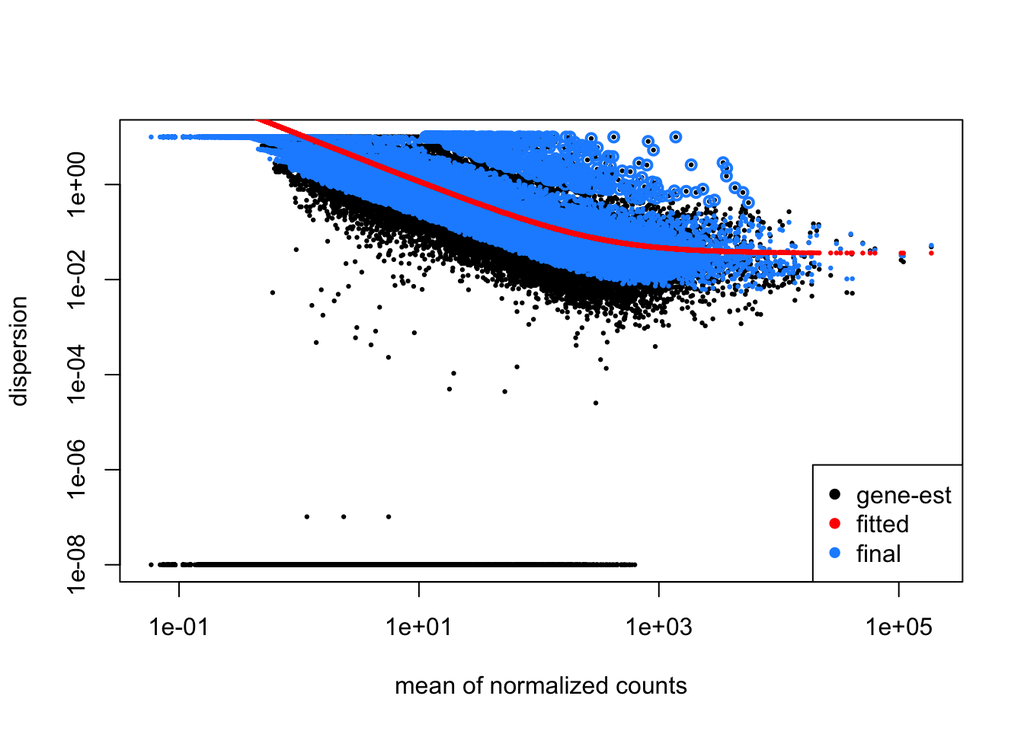

## PCA

```
## Importance of components:
##                            PC1     PC2     PC3     PC4     PC5      PC6
## Standard deviation     21.1891 17.0037 15.9478 14.1059 13.8734 13.22284
## Proportion of Variance  0.2384  0.1535  0.1351  0.1057  0.1022  0.09284
## Cumulative Proportion   0.2384  0.3919  0.5270  0.6327  0.7349  0.82769
##                             PC7      PC8       PC9
## Standard deviation     13.15108 12.31025 1.717e-13
## Proportion of Variance  0.09184  0.08047 0.000e+00
## Cumulative Proportion   0.91953  1.00000 1.000e+00
```

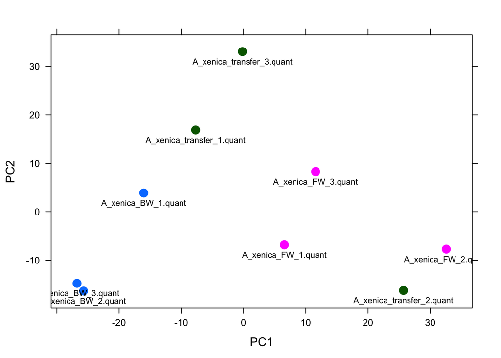

# Get normalized counts and filter out genes with low expression

This is the number of genes in the expression counts table:

```
## [1] 29421     9
```

After filtering for low expression (where th rowSum is greater than or equal to 1):

```
## [1] 18974     9
```

# MA plot, BW vs. FW

```
## [1] 29421     6
```

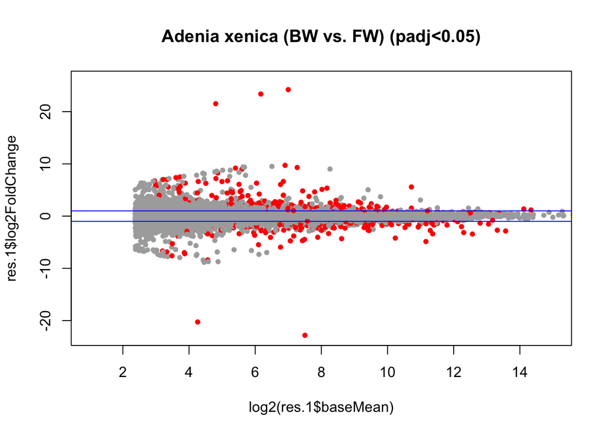

# MA plot, TR vs. FW

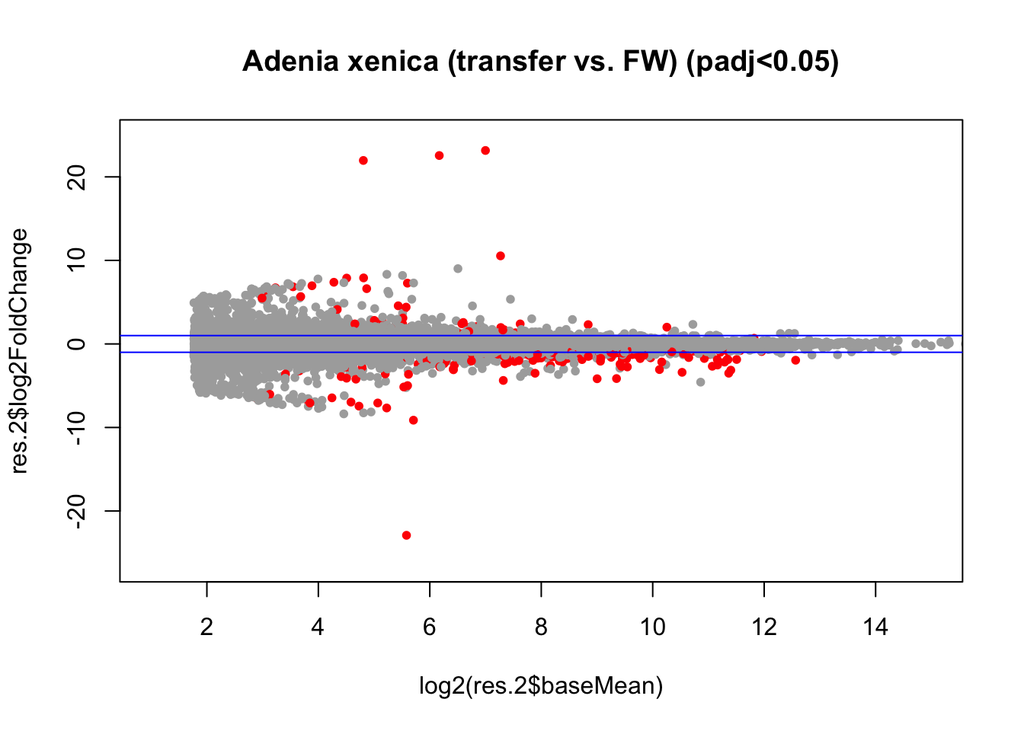

# MA plot, TR vs. BW

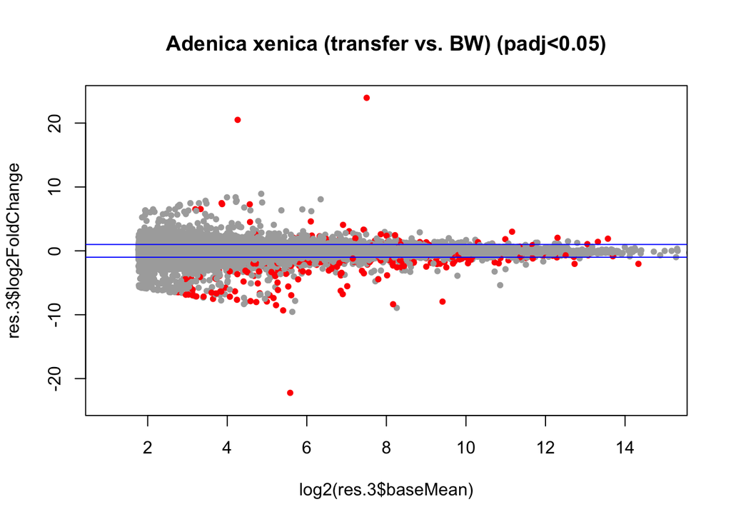

# Overlap of genes in each comparison

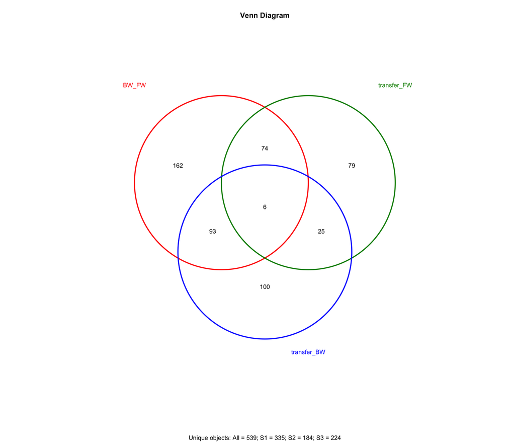

```
## [1] "BW_FW"                       "transfer_FW"
## [3] "transfer_BW"                 "BW_FWtransfer_FW"
## [5] "BW_FWtransfer_BW"            "transfer_FWtransfer_BW"
## [7] "BW_FWtransfer_FWtransfer_BW"
```

```
## [1] 74
```

```
## [1] 93
```

```
## [1] 25
```

```
## [1] 162
```

```
## [1] 79
```

```
## [1] 100
```

```
## [1] 162
```

```
## [1] 79
```

```
## [1] 100
```

# Heatmap, Transfer vs. FW

```
## [1] 79
```

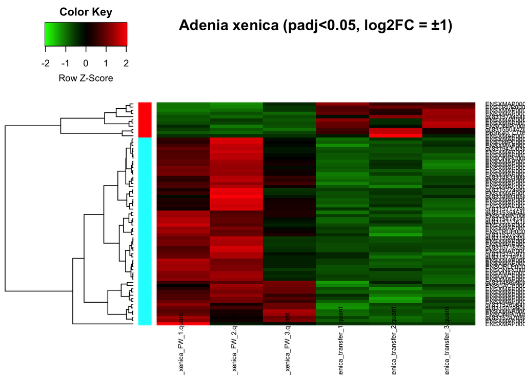

# Heatmap, Transfer vs. BW

```
## [1] 100
```

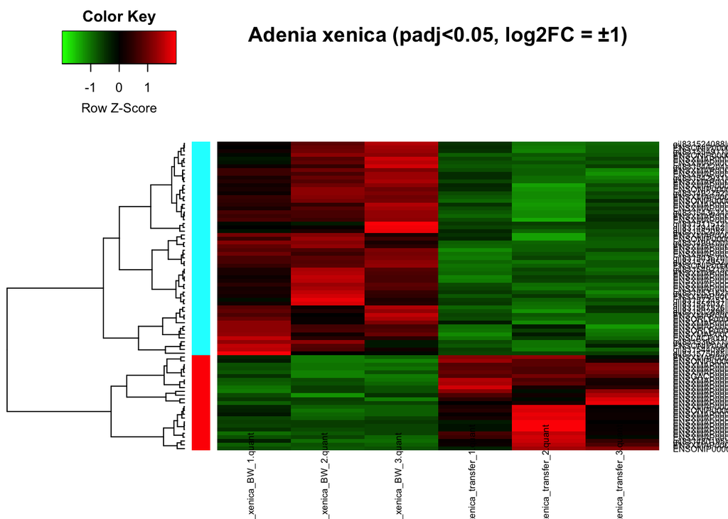